# Model fitting and selection using linear regression

Nnamdi Joseph Asouzu

8/22/2021

**CASE STUDY**

Low birth weight data: The goal of this study was to identify risk factors associated with giving birth to a low birth weight baby (weighing less than 2500 grams). Data were collected on 189 women, 59 of which had low birth weight babies and 130 of which had normal birth weight babies. Four variables which were thought to be of importance were age, weight of the subject at her last menstrual period, race, and the number of physician visits during the first trimester of pregnancy.

**ID Meaning**  
LOW Low BirthWeight (0 = BirthWeight >= 2500g, 1 = Birth Weight < 2500g)  
AGE Age of the Mother in Years  
LWT Weight in Pounds at the Last Menstrual Period  
RACE Race (1 = White, 2 = Black, 3 = Other)  
SMOKE Smoking Status During Pregnancy (1 = Yes, 0 = No)  
PTL History of Premature Labor (0 = None 1 = One, etc.)  
HT History of Hypertension (1 = Yes, 0 = No)  
UI Presence of Uterine Irritability (1 = Yes, 0 = No)  
FTV Number of Physician Visits During the First Trimester (0 = None, 1 = One, 2 = Two, etc.)  
BWT Birth Weight in Grams

*Use the continuous variable BWT as the response variable.*

**Analysis 1:**  
* Considering the four most clinically important variables previously discussed, i.e., age, weight of the subject at her last menstrual period, race, and the number of physician visits during the first trimester of pregnancy, carry out a model building exercise to determine the best model to describe the data. Based your model building exercise on the AIC and AIC weights. Discuss your results carefully.  
* Use backward elimination procedure to decide which predictor variables can be dropped from the regression model. Control the type I error at alpha = 0.10 at each stage. Which variables are retained? How does this compare to the results obtained with the AIC?

**Analysis 2:**  
* Consider now the 8 covariates included in the data set (all except Birth Weight in Grams). Repeat the previous model building exercise using the AIC and the AIC weights. Compare the results of both analysis and make a careful discussion. * Use backward elimination procedure to decide which predictor variables can be dropped from the regression model. Control the type I error at alpha = 0.10 at each stage. Which variables are retained? How does this compare to the results obtained with the AIC?

```r
suppressWarnings(suppressMessages(library("pastecs")))
suppressWarnings(suppressMessages(library("tidyverse")))
suppressWarnings(suppressMessages(library("PerformanceAnalytics")))
suppressWarnings(suppressMessages(library("AICcmodavg")))
```

**Import dataset**

```r
df <- read.table(file="C:/Users/Nnamdi/Desktop/Bioinformatics/Statistical_methods_for_bioinformatics/part_I/Projects/Project2/lowbwt.dat", header=T)
head(df)
```

|  | ID | LOW | AGE | LWT | RACE | SMOKE | PTL | HT | UI | FTV | BWT |
| --- | --- | --- | --- | --- | --- | --- | --- | --- | --- | --- | --- |
| 1 | 85 | 0 | 19 | 182 | 2 | 0 | 0 | 0 | 1 | 0 | 2523 |
| 2 | 86 | 0 | 33 | 155 | 3 | 0 | 0 | 0 | 0 | 3 | 2551 |
| 3 | 87 | 0 | 20 | 105 | 1 | 1 | 0 | 0 | 0 | 1 | 2557 |
| 4 | 88 | 0 | 21 | 108 | 1 | 1 | 0 | 0 | 1 | 2 | 2594 |
| 5 | 89 | 0 | 18 | 107 | 1 | 1 | 0 | 0 | 1 | 0 | 2600 |
| 6 | 91 | 0 | 21 | 124 | 3 | 0 | 0 | 0 | 0 | 0 | 2622 |

**ANALYSIS 1**

**Descriptive statistics**

```r
desc.df <- stat.desc(df[,c("AGE","LWT","RACE","SMOKE","PTL","HT","UI","FTV")], basic =T, desc=T)
desc.df
```

|  | AGE | LWT | RACE | SMOKE | PTL | HT | UI | FTV |
| --- | --- | --- | --- | --- | --- | --- | --- | --- |
| nbr.val | 189.0000000 | 1.890000e+02 | 189.00000000 | 189.00000000 | 189.00000000 | 189.00000000 | 189.00000000 | 189.00000000 |
| nbr.null | 0.0000000 | 0.000000e+00 | 0.00000000 | 115.00000000 | 159.00000000 | 177.00000000 | 161.00000000 | 100.00000000 |
| nbr.na | 0.0000000 | 0.000000e+00 | 0.00000000 | 0.00000000 | 0.00000000 | 0.00000000 | 0.00000000 | 0.00000000 |
| min | 14.0000000 | 8.000000e+01 | 1.00000000 | 0.00000000 | 0.00000000 | 0.00000000 | 0.00000000 | 0.00000000 |
| max | 45.0000000 | 2.500000e+02 | 3.00000000 | 1.00000000 | 3.00000000 | 1.00000000 | 1.00000000 | 6.00000000 |
| range | 31.0000000 | 1.700000e+02 | 2.00000000 | 1.00000000 | 3.00000000 | 1.00000000 | 1.00000000 | 6.00000000 |
| sum | 4392.0000000 | 2.453500e+04 | 349.00000000 | 74.00000000 | 37.00000000 | 12.00000000 | 28.00000000 | 150.00000000 |
| median | 23.0000000 | 1.210000e+02 | 1.00000000 | 0.00000000 | 0.00000000 | 0.00000000 | 0.00000000 | 0.00000000 |
| mean | 23.2380952 | 1.298148e+02 | 1.84656085 | 0.39153439 | 0.19576720 | 0.06349206 | 0.14814815 | 0.79365079 |
| SE.mean | 0.3854221 | 2.224323e+00 | 0.06679957 | 0.03559787 | 0.03588534 | 0.01778429 | 0.02590903 | 0.07705173 |

[output cut: 4 more lines]

```r
df$RACE <- as.factor(df$RACE)
df$FTV <- as.factor(df$FTV)
df$SMOKE <- as.factor(df$SMOKE)
df$PTL <- as.factor(df$PTL)
df$HT <- as.factor(df$HT)
df$UI <- as.factor(df$UI)
df$LOW <- as.factor(df$LOW)
```

**Exploratory data analysis**

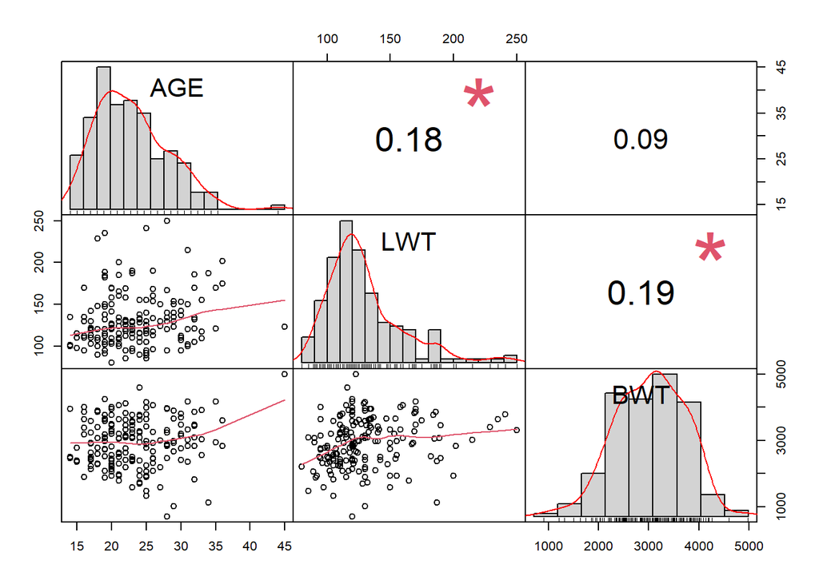

```r
chart.Correlation(df[,c(3,4,11)], histogram=TRUE, pch=19)
```

The birth weight of a new born baby increases when the age of the mother is 30 and above. This observation is supported by the medical condition called Macrosomia. Likewise, the birth weight of the baby increases with an increase in the weight of the mother before her last menstrual period.

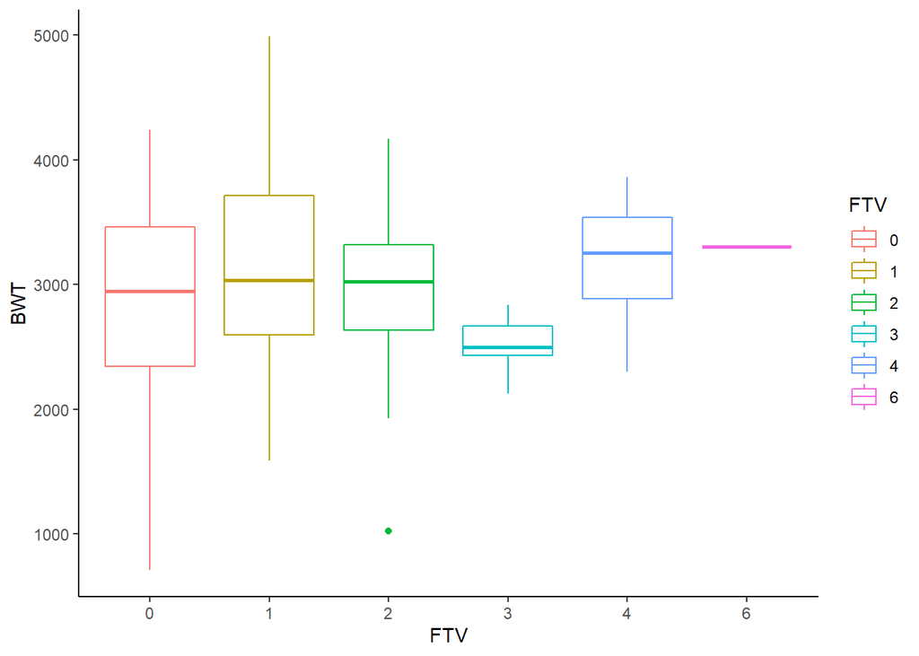

```r
ggplot(df,aes(FTV,BWT,color = FTV))+geom_boxplot() + theme_classic()
```

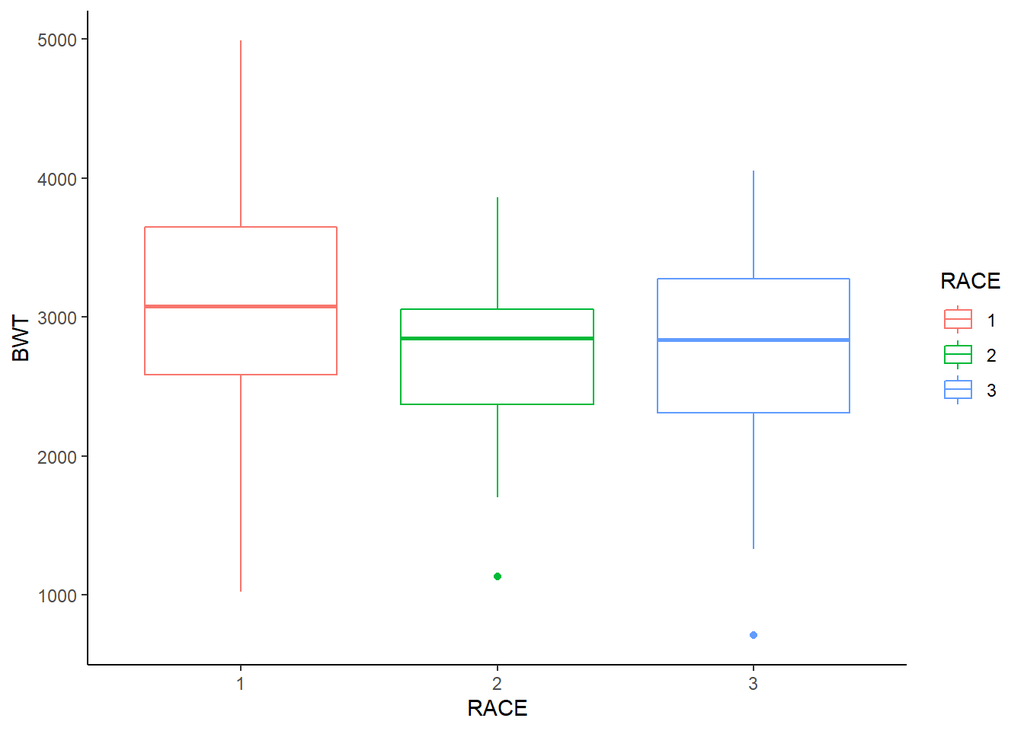

```r
ggplot(df,aes(RACE,BWT,color = RACE))+geom_boxplot() + theme_classic()
```

The plot shows that white women have babies with higher birth weight compared to African women or women from other ethnicity

**Fitting Models**

```r
mod <- lm(BWT ~ AGE+LWT+RACE+FTV, data=df)
summary (mod)
```

```
##
## Call:
## lm(formula = BWT ~ AGE + LWT + RACE + FTV, data = df)
##
## Residuals:
##      Min       1Q   Median       3Q      Max
## -2072.27  -412.00    66.29   483.13  1835.90
##
## Coefficients:
##             Estimate Std. Error t value Pr(>|t|)
## (Intercept) 2460.544    326.560   7.535 2.34e-12 ***
## AGE           -2.119     10.396  -0.204  0.83869
## LWT            4.738      1.896   2.499  0.01335 *
## RACE2       -448.680    161.637  -2.776  0.00609 **
## RACE3       -217.308    118.051  -1.841  0.06731 .
## FTV1         206.201    129.085   1.597  0.11194
## FTV2          78.297    149.932   0.522  0.60217
## FTV3        -335.867    277.057  -1.212  0.22701
## FTV4         292.378    361.302   0.809  0.41946
## FTV6         -65.298    751.976  -0.087  0.93090
## ---
## Signif. codes:  0 '***' 0.001 '**' 0.01 '*' 0.05 '.' 0.1 ' ' 1
##
## Residual standard error: 704 on 179 degrees of freedom
## Multiple R-squared:  0.112,  Adjusted R-squared:  0.06736
## F-statistic: 2.509 on 9 and 179 DF,  p-value: 0.009973
```

**Forward Selection using AICc score**

```r
mod.list <- list()
mod.list[[1]] <- lm(BWT ~ AGE+LWT+RACE+FTV, data=df)
mod.list[[2]]<- lm(BWT ~ AGE*FTV+AGE*LWT+AGE*RACE+LWT*RACE+LWT*FTV+RACE*FTV, data = df)
mod.list[[3]] <- lm(BWT ~ AGE+LWT+RACE, data=df)
mod.list[[4]] <- lm(BWT ~ AGE+FTV+RACE, data=df)
mod.list[[5]] <- lm(BWT ~ FTV+LWT+RACE, data=df)
mod.list[[6]] <- lm(BWT ~ AGE+LWT*RACE, data=df)
mod.list[[7]] <- lm(BWT ~ AGE+FTV*RACE, data=df)

mod.aictab=aictab(cand.set = mod.list)
mod.aictab
```

|  | Modnames | K | AICc | Delta_AICc | ModelLik | AICcWt | LL | Cum.Wt |
| --- | --- | --- | --- | --- | --- | --- | --- | --- |
| 3 | Mod3 | 6 | 3022.518 | 0.000000 | 1.000000e+00 | 7.073178e-01 | -1505.028 | 0.7073178 |
| 5 | Mod5 | 10 | 3025.848 | 3.330507 | 1.891427e-01 | 1.337840e-01 | -1502.306 | 0.8411018 |
| 6 | Mod6 | 8 | 3026.253 | 3.735322 | 1.544846e-01 | 1.092697e-01 | -1504.727 | 0.9503716 |
| 1 | Mod1 | 11 | 3028.060 | 5.542196 | 6.259323e-02 | 4.427330e-02 | -1502.284 | 0.9946449 |
| 4 | Mod4 | 10 | 3032.287 | 9.769192 | 7.562178e-03 | 5.348863e-03 | -1505.526 | 0.9999937 |
| 7 | Mod7 | 18 | 3045.792 | 23.274626 | 8.830374e-06 | 6.245881e-06 | -1502.884 | 1.0000000 |
| 2 | Mod2 | 31 | 3057.119 | 34.601014 | 3.065386e-08 | 2.168202e-08 | -1491.241 | 1.0000000 |

The model fitted by forward selection technique using the lowest AICc score is **BWT ~ AGE + LWT + RACE**.

**Backward selection using cut-off p-value < 0.10**

```r
df.mod <- lm(BWT~AGE+LWT+RACE+FTV, data = df)
summary(df.mod)
```

```
##
## Call:
## lm(formula = BWT ~ AGE + LWT + RACE + FTV, data = df)
##
## Residuals:
##      Min       1Q   Median       3Q      Max
## -2072.27  -412.00    66.29   483.13  1835.90
##
## Coefficients:
##             Estimate Std. Error t value Pr(>|t|)
## (Intercept) 2460.544    326.560   7.535 2.34e-12 ***
## AGE           -2.119     10.396  -0.204  0.83869
## LWT            4.738      1.896   2.499  0.01335 *
## RACE2       -448.680    161.637  -2.776  0.00609 **
## RACE3       -217.308    118.051  -1.841  0.06731 .
## FTV1         206.201    129.085   1.597  0.11194
## FTV2          78.297    149.932   0.522  0.60217
## FTV3        -335.867    277.057  -1.212  0.22701
## FTV4         292.378    361.302   0.809  0.41946
## FTV6         -65.298    751.976  -0.087  0.93090
## ---
## Signif. codes:  0 '***' 0.001 '**' 0.01 '*' 0.05 '.' 0.1 ' ' 1
##
## Residual standard error: 704 on 179 degrees of freedom
## Multiple R-squared:  0.112,  Adjusted R-squared:  0.06736
## F-statistic: 2.509 on 9 and 179 DF,  p-value: 0.009973
```

Remove the variable with p-value above the cut off score

```r
df.mod2 <- update(df.mod, . ~ . - FTV, data = df)
summary(df.mod2)
```

```
##
## Call:
## lm(formula = BWT ~ AGE + LWT + RACE, data = df)
##
## Residuals:
##      Min       1Q   Median       3Q      Max
## -2101.67  -427.25    40.48   484.60  1903.22
##
## Coefficients:
##             Estimate Std. Error t value Pr(>|t|)
## (Intercept) 2464.988    314.556   7.836  3.6e-13 ***
## AGE            1.199     10.102   0.119  0.90566
## LWT            4.617      1.787   2.584  0.01055 *
## RACE2       -448.867    161.284  -2.783  0.00595 **
## RACE3       -241.872    115.128  -2.101  0.03701 *
## ---
## Signif. codes:  0 '***' 0.001 '**' 0.01 '*' 0.05 '.' 0.1 ' ' 1
##
## Residual standard error: 704.6 on 184 degrees of freedom
## Multiple R-squared:  0.08585,    Adjusted R-squared:  0.06597
## F-statistic:  4.32 on 4 and 184 DF,  p-value: 0.002307
```

Age has a p -value greater than 0.1 but we will include it in the model because it is known that maternal age affects birth weight of babies ( a condition known as Macrosomia)

Thus, the model fitted by backward selection technique using control p-value less than 0.10 is **BWT ~ AGE + LWT + RACE**. This model is same as the model fitted using the forward selection.

**ANALYSIS 2**

**Exploratory data analysis**

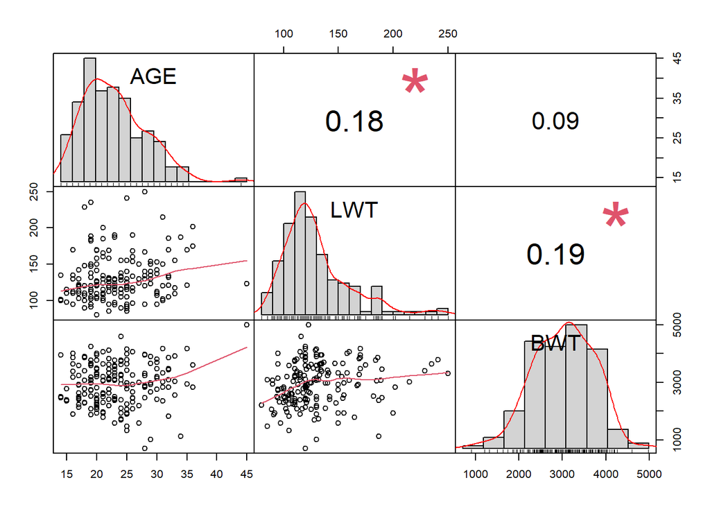

```r
chart.Correlation(df[,-c(1,2,5:10)], histogram=TRUE, pch=19)
```

The birth weight of a new born baby increases when the age of the mother is 30 and above. This observation is supported by the medical condition called Macrosomia. Likewise, the birth weight of the baby increases with an increase in the weight of the mother before her last menstrual period.

Boxplots

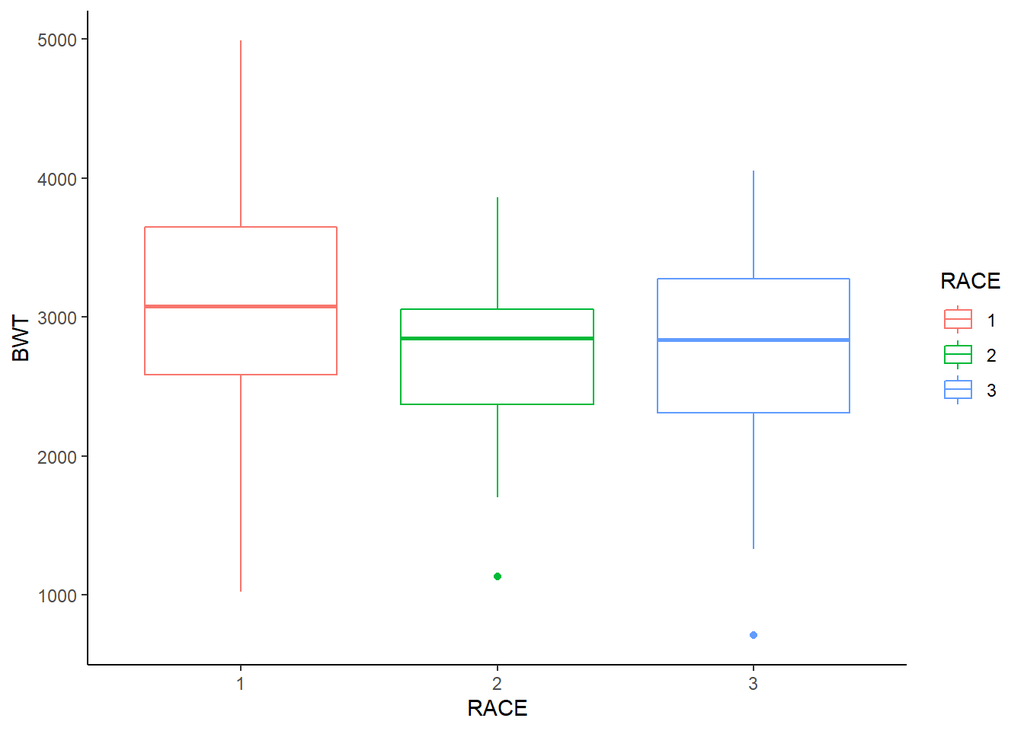

```r
ggplot(df,aes(RACE,BWT,color = RACE))+geom_boxplot() + theme_classic()
```

The plot shows that white women have babies with higher birth weight compared to African women or women from other ethnicity

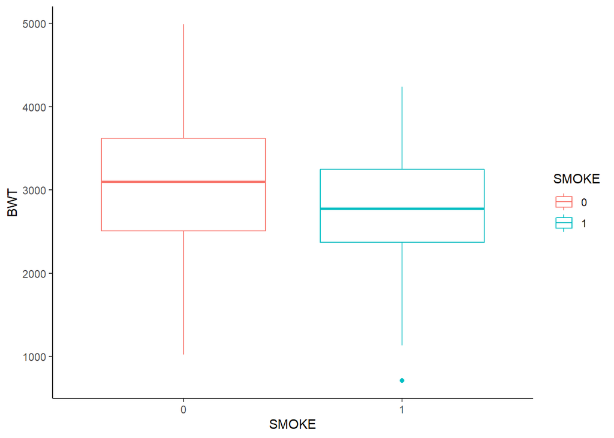

```r
ggplot(df,aes(SMOKE,BWT,color = SMOKE))+geom_boxplot() + theme_classic()
```

The barplot shows that women who smoked cigarettes during pregnancy had babies with lower birth weight compared to non-smokers pregnant women.

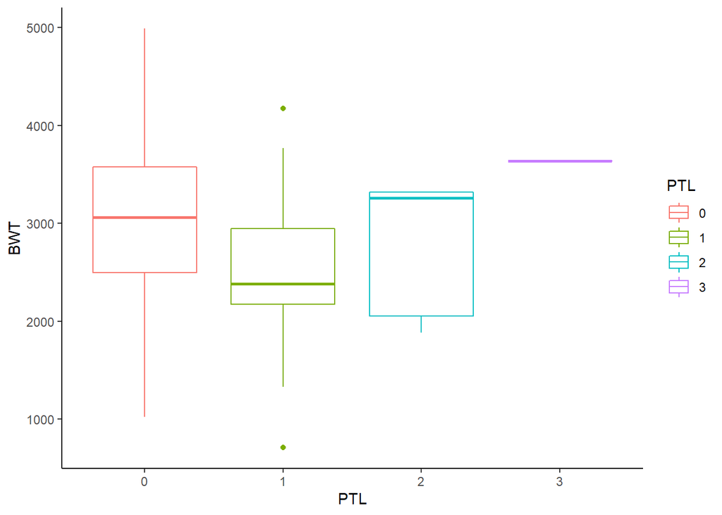

```r
ggplot(df,aes(PTL,BWT,color = PTL))+geom_boxplot() + theme_classic()
```

The barplot shows that women with the highest history(3 times) of premature labor had babies with higher weight compared to other women with lesser number of premature labor.

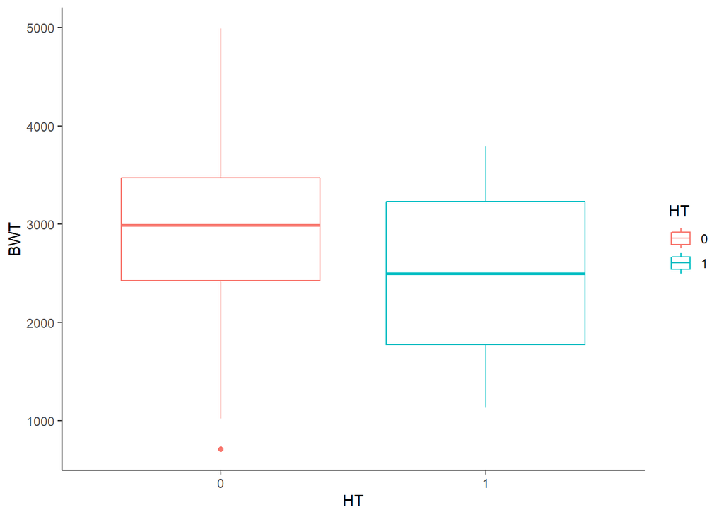

```r
ggplot(df,aes(HT,BWT,color = HT))+geom_boxplot() + theme_classic()
```

The plot shows that women with hypertension had babies with lower birth weight compared to women without hypertension.

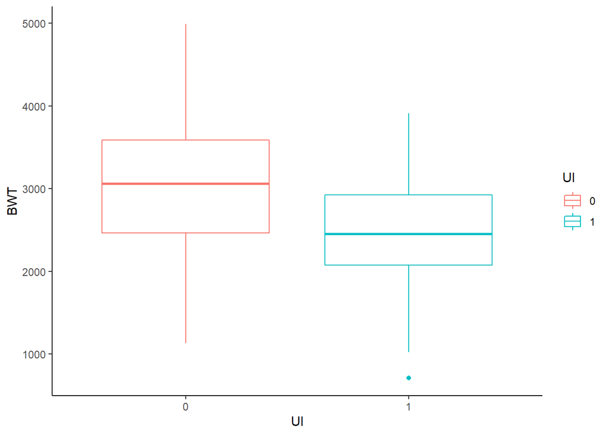

```r
ggplot(df,aes(UI,BWT,color = UI))+geom_boxplot() + theme_classic()
```

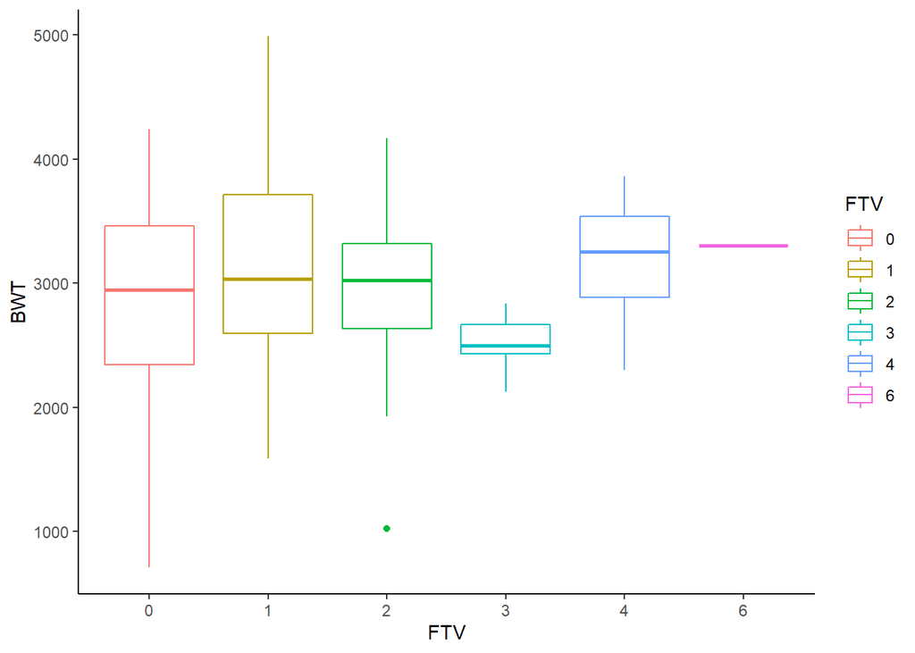

```r
ggplot(df,aes(FTV,BWT,color = FTV))+geom_boxplot() + theme_classic()
```

**Fitting Models**

**Model building using forward selection technique and AICc score**

```r
mod.list2 <- list()
mod.list2[[1]] <- lm(BWT ~ AGE+LWT+RACE+SMOKE+PTL+HT+UI+FTV, data=df)
mod.list2[[2]]<- lm(BWT ~ LWT+RACE+SMOKE+PTL+HT+UI, data = df)
mod.list2[[3]] <- lm(BWT ~ AGE+LWT+RACE+SMOKE+PTL+HT+UI, data = df)
mod.list2[[4]] <- lm(BWT ~ LWT*RACE+LWT*SMOKE+LWT*PTL+LWT*HT+LWT*UI, data=df)
mod.list2[[5]] <- lm(BWT ~ AGE+RACE*HT+RACE*UI+LWT*RACE+SMOKE*PTL+SMOKE*HT+SMOKE*RACE, data=df)
mod.list2[[6]] <- lm(BWT ~ LWT+RACE+SMOKE+PTL+HT+UI+RACE*UI, data=df)



mod.aictab2=aictab(cand.set = mod.list2)
mod.aictab2
```

|  | Modnames | K | AICc | Delta_AICc | ModelLik | AICcWt | LL | Cum.Wt |
| --- | --- | --- | --- | --- | --- | --- | --- | --- |
| 2 | Mod2 | 11 | 2989.836 | 0.000000 | 1.0000000000 | 0.6324322821 | -1483.172 | 0.6324323 |
| 3 | Mod3 | 12 | 2992.054 | 2.217830 | 0.3299166962 | 0.2086499691 | -1483.141 | 0.8410823 |
| 6 | Mod6 | 13 | 2992.927 | 3.090244 | 0.2132858383 | 0.1348888494 | -1482.423 | 0.9759711 |
| 4 | Mod4 | 18 | 2996.812 | 6.975353 | 0.0305718268 | 0.0193346102 | -1478.394 | 0.9953057 |
| 1 | Mod1 | 17 | 2999.733 | 9.896132 | 0.0070971200 | 0.0044884478 | -1481.077 | 0.9997942 |
| 5 | Mod5 | 23 | 3005.897 | 16.060444 | 0.0003254759 | 0.0002058415 | -1476.603 | 1.0000000 |

The model fitted by forward selection technique using AICc score is  
**BWT ~ AGE+LWT+RACE+SMOKE+PTL+HT+UI**.  
Although this model did not have the lowest AICc score, it is logical to include the mother’s age as one of the predictors of the birth weight of a baby because it is known that maternal age influences the birth weight of babies as seen in published articles

**Backward selection using p-value < 0.10**

```r
mod2 <- lm(BWT ~ AGE+LWT+RACE+SMOKE+PTL+HT+UI+FTV, data=df)
summary (mod2)  ## full model
```

```
##
## Call:
## lm(formula = BWT ~ AGE + LWT + RACE + SMOKE + PTL + HT + UI +
##     FTV, data = df)
##
## Residuals:
##      Min       1Q   Median       3Q      Max
## -1780.02  -425.78    55.22   477.63  1602.10
##
## Coefficients:
##             Estimate Std. Error t value Pr(>|t|)
## (Intercept) 2843.315    328.826   8.647 3.49e-15 ***
## AGE           -3.037      9.602  -0.316  0.75219
## LWT            4.379      1.835   2.387  0.01806 *
## RACE2       -443.362    148.895  -2.978  0.00332 **
## RACE3       -284.159    120.723  -2.354  0.01970 *
## SMOKE1      -282.149    111.725  -2.525  0.01246 *
## PTL1        -357.438    152.293  -2.347  0.02005 *
## PTL2         -69.720    297.439  -0.234  0.81495
## PTL3        1257.202    661.526   1.900  0.05904 .
## HT1         -552.983    202.150  -2.736  0.00688 **
## UI1         -521.490    138.135  -3.775  0.00022 ***
## FTV1         142.579    122.799   1.161  0.24721
## FTV2          -2.055    138.630  -0.015  0.98819
## FTV3        -320.290    253.931  -1.261  0.20889
## FTV4         245.413    336.895   0.728  0.46732
## FTV6          16.178    700.711   0.023  0.98161
## ---
## Signif. codes:  0 '***' 0.001 '**' 0.01 '*' 0.05 '.' 0.1 ' ' 1
##
## Residual standard error: 640.1 on 173 degrees of freedom
## Multiple R-squared:  0.2905, Adjusted R-squared:  0.229
## F-statistic: 4.722 on 15 and 173 DF,  p-value: 1.377e-07
```

remove variables with p-value > 0.1

```r
clean.mod2 <- update(mod2, . ~ . - FTV, data = df)
summary(clean.mod2)
```

```
##
## Call:
## lm(formula = BWT ~ AGE + LWT + RACE + SMOKE + PTL + HT + UI,
##     data = df)
##
## Residuals:
##      Min       1Q   Median       3Q      Max
## -1820.01  -438.38    39.08   492.98  1672.69
##
## Coefficients:
##             Estimate Std. Error t value Pr(>|t|)
## (Intercept) 2881.166    307.547   9.368  < 2e-16 ***
## AGE           -2.287      9.360  -0.244 0.807263
## LWT            4.383      1.695   2.585 0.010525 *
## RACE2       -454.396    148.052  -3.069 0.002483 **
## RACE3       -317.192    113.295  -2.800 0.005680 **
## SMOKE1      -331.654    104.851  -3.163 0.001836 **
## PTL1        -288.586    146.077  -1.976 0.049748 *
## PTL2         -15.947    294.370  -0.054 0.956857
## PTL3        1271.887    657.139   1.935 0.054515 .
## HT1         -576.642    197.752  -2.916 0.004002 **
## UI1         -543.569    136.773  -3.974 0.000102 ***
## ---
## Signif. codes:  0 '***' 0.001 '**' 0.01 '*' 0.05 '.' 0.1 ' ' 1
##
## Residual standard error: 638 on 178 degrees of freedom
## Multiple R-squared:  0.2748, Adjusted R-squared:  0.2341
## F-statistic: 6.746 on 10 and 178 DF,  p-value: 7.118e-09
```

Age has a p -value greater than 0.1 but we will include it in the model because it is known that maternal age affects birth weight of babies (a condition known as Macrosomia).

The model fitted by backward selection technique using control p-value less than 0.10 is:  
**BWT ~ AGE + LWT + RACE + SMOKE + PTL + HT + UI**. This model is similar to the model fitted using forward selection technique and AICc score .

```r
final_model = lm(BWT ~ AGE + LWT + RACE + SMOKE + PTL + HT + UI, data=df)
summary(final_model)
```

```
##
## Call:
## lm(formula = BWT ~ AGE + LWT + RACE + SMOKE + PTL + HT + UI,
##     data = df)
##
## Residuals:
##      Min       1Q   Median       3Q      Max
## -1820.01  -438.38    39.08   492.98  1672.69
##
## Coefficients:
##             Estimate Std. Error t value Pr(>|t|)
## (Intercept) 2881.166    307.547   9.368  < 2e-16 ***
## AGE           -2.287      9.360  -0.244 0.807263
## LWT            4.383      1.695   2.585 0.010525 *
## RACE2       -454.396    148.052  -3.069 0.002483 **
## RACE3       -317.192    113.295  -2.800 0.005680 **
## SMOKE1      -331.654    104.851  -3.163 0.001836 **
## PTL1        -288.586    146.077  -1.976 0.049748 *
## PTL2         -15.947    294.370  -0.054 0.956857
## PTL3        1271.887    657.139   1.935 0.054515 .
## HT1         -576.642    197.752  -2.916 0.004002 **
## UI1         -543.569    136.773  -3.974 0.000102 ***
## ---
## Signif. codes:  0 '***' 0.001 '**' 0.01 '*' 0.05 '.' 0.1 ' ' 1
##
## Residual standard error: 638 on 178 degrees of freedom
## Multiple R-squared:  0.2748, Adjusted R-squared:  0.2341
## F-statistic: 6.746 on 10 and 178 DF,  p-value: 7.118e-09
```

**Confidence interval**

```r
cbind(Estimate=final_model$coefficients,confint(final_model))
```

```
##                Estimate       2.5 %       97.5 %
## (Intercept) 2881.166062 2274.259051 3488.0730734
## AGE           -2.286803  -20.757216   16.1836100
## LWT            4.382529    1.037519    7.7275400
## RACE2       -454.396243 -746.558479 -162.2340068
## RACE3       -317.191586 -540.765599  -93.6175722
## SMOKE1      -331.654157 -538.564229 -124.7440858
## PTL1        -288.586446 -576.851469   -0.3214225
## PTL2         -15.947309 -596.851805  564.9571868
## PTL3        1271.886767  -24.899204 2568.6727389
## HT1         -576.641959 -966.882042 -186.4018754
## UI1         -543.568879 -813.473310 -273.6644467
```